# 1. Introdução

Autor: Maicon Henrique Cunha

Base de dados: winiquality.csv contendo doze variáveis de entrada e uma variável de saída com notas entre 0 e 10

Objetivo: Criar um modelo para estimar a qualidade do vinho

Linguagem utilizada: Python

O trabalho está organizada da seguinte forma:

1. Introdução
   - Discussão Regressão x Classificação
   - Importação de pacotes
1. Análise de inconsistência e preparação dos dados
   - Remoção de amostras com valores incosistentes de alcohol
   - Remoção de amostras com valores inconsistentes de density
   - Remoção de outliers
   - Visualização da distribuição dos dados
   - Regularização dos dados
   - Criação das categorias: baixa, média e alta
1. Análise exploratória dos dados
   - Avaliação das variáveis mais importantes sem distinção de vinho branco o vermelho
   - Separação entre vinho branco e vermelho
   - Comparação entre as médias dos vinhos branco e vermelho
   - Comparação entre as diferenças dos vinhos branco e vermelho ruins e bons
   - Análise multivariada sem distinção de vinho branco e vermelho
   - Análise multivariada com distinção de vinho branco e vermelho
   - Resumo das observações obtidas
1. Testes com modelos de ML
   - Criação das variáveis de entrada e saída para os modelos
   - Testes com Regressão Linear,SVM,Linear SVM,Regressão Logística,Xgboost e Árvore de decisão. Kfold = 20
   - Implementação de gridsearch para XGBoost e escolhas dos melhores parâmetros
   - Teste dos melhores parâmetros obtidos para XGBoost com kfold = 20. RMSE = 0.58
1. Apresentação do modelo escolhido e conclusão
   - Separação dos dados em treinamento e teste (80/20) com resultados do teste salvos em resultado.csv e modelo salvo em modelo_teste.bin
   - Apresentação das variáveis mais importantes para o modelo
   - Apresentação do início da árvore de decisão
   - Criação de um modelo com todos os dados (modelo.bin) com exemplo de utilização em apply_model.ipynb
   - Conclusões finais

### Discussão: Regressão x Classificação

Embora as notas não sejam valores contínuos nesse trabalho será utilizada a abordagem da regressão. O porque dessa abordagem fica claro com o exemplo:

Caso1 - suponha que em 10 amostras para testes 2 estejam erradas: No erro 1 a nota original era 5 e o modelo avaliou como 6 No erro 2 a nota original era 7 e o modelo avaliou como 8

Caso2 - suponha que em 10 amostras para testes 2 estejam erradas: No erro 1 a nota original era 5 e o modelo avaliou como 8 No erro 2 a nota original era 7 e o modelo avaliou como 4

Claramente os dois erros são diferentes! Porém se estivéssemos utilizando classificação teríamos uma mesma acurácia de 80%.

Com um modelo de regressão e utilizando raiz do erro quadrático médio (RMSE) por exemplo essas diferenças são levadas em consideração, sendo esse o motivo de utilizar regressão e como função de custo a raiz do erro quadrático médio

### Importação de pacotes necessários

```python
import pandas as pd
import matplotlib.pyplot as plt
import seaborn as sns
import numpy as np
from sklearn.preprocessing import MinMaxScaler
from sklearn.model_selection import train_test_split
from sklearn.metrics import mean_squared_error
from sklearn.linear_model import LinearRegression
from sklearn.tree import DecisionTreeRegressor
import xgboost as xgb
import sys
from sklearn import svm
from sklearn.model_selection import KFold
from sklearn.linear_model import Lasso
from sklearn.linear_model import LogisticRegression
from sklearn.model_selection import StratifiedKFold
from sklearn.model_selection import RandomizedSearchCV
from xgboost import plot_tree
import warnings
warnings.simplefilter(action='ignore', category=FutureWarning)
pd.options.mode.chained_assignment = None
%matplotlib inline
```

# 2. Análise de Inconsistências e Preparação dos Dados

### Leitura

```python
df = pd.read_csv("winequality.csv",sep =";")
```

### Cabeçalho

```python
df.head()
```

|  | type | fixed acidity | volatile acidity | citric acid | residual sugar | chlorides | free sulfur dioxide | total sulfur dioxide | density | pH | sulphates | alcohol | quality |
| --- | --- | --- | --- | --- | --- | --- | --- | --- | --- | --- | --- | --- | --- |
| 0 | White | 7.0 | 0.27 | 0.36 | 20.7 | 0.045 | 45.0 | 170.0 | 1.0010 | 3.00 | 0.45 | 8.8 | 6 |
| 1 | White | 6.3 | 0.30 | 0.34 | 1.6 | 0.049 | 14.0 | 132.0 | 0.9940 | 3.30 | 0.49 | 9.5 | 6 |
| 2 | White | 8.1 | 0.28 | 0.40 | 6.9 | 0.050 | 30.0 | 97.0 | 0.9951 | 3.26 | 0.44 | 10.1 | 6 |
| 3 | White | 7.2 | 0.23 | 0.32 | 8.5 | 0.058 | 47.0 | 186.0 | 0.9956 | 3.19 | 0.40 | 9.9 | 6 |
| 4 | White | 7.2 | 0.23 | 0.32 | 8.5 | 0.058 | 47.0 | 186.0 | 0.9956 | 3.19 | 0.40 | 9.9 | 6 |

### Informações Iniciais

```python
df.info()
```

```
<class 'pandas.core.frame.DataFrame'>
RangeIndex: 6497 entries, 0 to 6496
Data columns (total 13 columns):
type                    6497 non-null object
fixed acidity           6497 non-null float64
volatile acidity        6497 non-null float64
citric acid             6497 non-null float64
residual sugar          6497 non-null float64
chlorides               6497 non-null float64
free sulfur dioxide     6497 non-null float64
total sulfur dioxide    6497 non-null float64
density                 6497 non-null float64
pH                      6497 non-null float64
sulphates               6497 non-null float64
alcohol                 6497 non-null object
quality                 6497 non-null int64
dtypes: float64(10), int64(1), object(2)
memory usage: 659.9+ KB
```

#### Transformando a variável type em categoria

```python
df["type"] = df["type"].astype("category")
```

#### Obs: a variável alcohol não aparece como float e deve ser investigada

```python
try:
    df["alcohol"] = df["alcohol"].astype("float")
except:
    print("Erro - "+str(sys.exc_info()[1]))
```

```
Erro - could not convert string to float: '128.933.333.333.333'
```

```python
df['alcohol'] = pd.to_numeric(df['alcohol'],errors='coerce')
```

#### Obs: 40 amostras possuíam alcohol em formato não permitido e foram tranformadas em null

```python
df.info()
```

```
<class 'pandas.core.frame.DataFrame'>
RangeIndex: 6497 entries, 0 to 6496
Data columns (total 13 columns):
type                    6497 non-null category
fixed acidity           6497 non-null float64
volatile acidity        6497 non-null float64
citric acid             6497 non-null float64
residual sugar          6497 non-null float64
chlorides               6497 non-null float64
free sulfur dioxide     6497 non-null float64
total sulfur dioxide    6497 non-null float64
density                 6497 non-null float64
pH                      6497 non-null float64
sulphates               6497 non-null float64
alcohol                 6457 non-null float64
quality                 6497 non-null int64
dtypes: category(1), float64(11), int64(1)
memory usage: 615.6 KB
```

#### Eliminando as linhas com valores nulos para alcohol

```python
df = df.dropna()
```

```python
df.info()
```

```
<class 'pandas.core.frame.DataFrame'>
Int64Index: 6457 entries, 0 to 6496
Data columns (total 13 columns):
type                    6457 non-null category
fixed acidity           6457 non-null float64
volatile acidity        6457 non-null float64
citric acid             6457 non-null float64
residual sugar          6457 non-null float64
chlorides               6457 non-null float64
free sulfur dioxide     6457 non-null float64
total sulfur dioxide    6457 non-null float64
density                 6457 non-null float64
pH                      6457 non-null float64
sulphates               6457 non-null float64
alcohol                 6457 non-null float64
quality                 6457 non-null int64
dtypes: category(1), float64(11), int64(1)
memory usage: 662.2 KB
```

### Descrevendo o conjunto de Dados

```python
df.describe()
```

|  | fixed acidity | volatile acidity | citric acid | residual sugar | chlorides | free sulfur dioxide | total sulfur dioxide | density | pH | sulphates | alcohol | quality |
| --- | --- | --- | --- | --- | --- | --- | --- | --- | --- | --- | --- | --- |
| count | 6457.000000 | 6457.000000 | 6457.000000 | 6457.000000 | 6457.000000 | 6457.000000 | 6457.000000 | 6457.000000 | 6457.000000 | 6457.000000 | 6457.000000 | 6457.000000 |
| mean | 7.219475 | 0.339684 | 0.318795 | 5.445973 | 0.056081 | 30.495586 | 115.690801 | 1.715329 | 3.218592 | 0.531169 | 10.489083 | 5.817098 |
| std | 1.294910 | 0.164690 | 0.145506 | 4.764308 | 0.035110 | 17.757007 | 56.595196 | 7.659497 | 0.160845 | 0.148870 | 1.192961 | 0.874125 |
| min | 3.800000 | 0.080000 | 0.000000 | 0.600000 | 0.009000 | 1.000000 | 6.000000 | 0.987110 | 2.720000 | 0.220000 | 8.000000 | 3.000000 |
| 25% | 6.400000 | 0.230000 | 0.250000 | 1.800000 | 0.038000 | 17.000000 | 77.000000 | 0.992350 | 3.110000 | 0.430000 | 9.500000 | 5.000000 |
| 50% | 7.000000 | 0.290000 | 0.310000 | 3.000000 | 0.047000 | 29.000000 | 118.000000 | 0.994900 | 3.210000 | 0.510000 | 10.300000 | 6.000000 |
| 75% | 7.700000 | 0.400000 | 0.390000 | 8.100000 | 0.065000 | 41.000000 | 156.000000 | 0.997000 | 3.320000 | 0.600000 | 11.300000 | 6.000000 |
| max | 15.900000 | 1.580000 | 1.660000 | 65.800000 | 0.611000 | 289.000000 | 440.000000 | 103.898000 | 4.010000 | 2.000000 | 14.900000 | 9.000000 |

#### Obs: o valor máximo para desidade aparece como 103.89, porém esas densidade não faz sentido para vinho

```python
densidade_errada = df[df["density"]>1.1]
```

```python
densidade_errada.head()
```

|  | type | fixed acidity | volatile acidity | citric acid | residual sugar | chlorides | free sulfur dioxide | total sulfur dioxide | density | pH | sulphates | alcohol | quality |
| --- | --- | --- | --- | --- | --- | --- | --- | --- | --- | --- | --- | --- | --- |
| 14 | White | 8.3 | 0.42 | 0.62 | 19.25 | 0.040 | 41.0 | 172.0 | 10.002 | 2.98 | 0.67 | 9.7 | 5 |
| 717 | White | 7.0 | 0.27 | 0.41 | 18.75 | 0.042 | 34.0 | 157.0 | 10.002 | 2.96 | 0.50 | 9.1 | 5 |
| 762 | White | 6.8 | 0.24 | 0.49 | 19.30 | 0.057 | 55.0 | 247.0 | 100.055 | 3.00 | 0.56 | 8.7 | 5 |
| 779 | White | 8.1 | 0.17 | 0.44 | 14.10 | 0.053 | 43.0 | 145.0 | 10.006 | 3.28 | 0.75 | 8.8 | 8 |
| 783 | White | 8.1 | 0.17 | 0.44 | 14.10 | 0.053 | 43.0 | 145.0 | 10.006 | 3.28 | 0.75 | 8.8 | 8 |

#### Removendo os dados com densidade errada

```python
df = df[df["density"]<=1.1]
```

```python
df.describe()
```

|  | fixed acidity | volatile acidity | citric acid | residual sugar | chlorides | free sulfur dioxide | total sulfur dioxide | density | pH | sulphates | alcohol | quality |
| --- | --- | --- | --- | --- | --- | --- | --- | --- | --- | --- | --- | --- |
| count | 6321.000000 | 6321.000000 | 6321.000000 | 6321.000000 | 6321.000000 | 6321.000000 | 6321.000000 | 6321.000000 | 6321.000000 | 6321.000000 | 6321.000000 | 6321.000000 |
| mean | 7.166690 | 0.338840 | 0.316168 | 5.311296 | 0.055706 | 30.484101 | 115.590729 | 0.994566 | 3.219780 | 0.529018 | 10.508307 | 5.821864 |
| std | 1.202892 | 0.164502 | 0.144048 | 4.546028 | 0.035076 | 17.700433 | 56.026335 | 0.002824 | 0.160915 | 0.147882 | 1.188949 | 0.874880 |
| min | 3.800000 | 0.080000 | 0.000000 | 0.600000 | 0.009000 | 1.000000 | 6.000000 | 0.987110 | 2.720000 | 0.220000 | 8.000000 | 3.000000 |
| 25% | 6.400000 | 0.230000 | 0.240000 | 1.800000 | 0.038000 | 17.000000 | 78.000000 | 0.992290 | 3.110000 | 0.430000 | 9.500000 | 5.000000 |
| 50% | 7.000000 | 0.290000 | 0.310000 | 2.900000 | 0.047000 | 29.000000 | 118.000000 | 0.994800 | 3.210000 | 0.500000 | 10.300000 | 6.000000 |
| 75% | 7.600000 | 0.400000 | 0.390000 | 8.000000 | 0.064000 | 41.000000 | 155.000000 | 0.996800 | 3.320000 | 0.600000 | 11.300000 | 6.000000 |
| max | 15.900000 | 1.580000 | 1.660000 | 22.600000 | 0.611000 | 289.000000 | 440.000000 | 1.001000 | 4.010000 | 2.000000 | 14.900000 | 9.000000 |

```python
df.info()
```

```
<class 'pandas.core.frame.DataFrame'>
Int64Index: 6321 entries, 0 to 6496
Data columns (total 13 columns):
type                    6321 non-null category
fixed acidity           6321 non-null float64
volatile acidity        6321 non-null float64
citric acid             6321 non-null float64
residual sugar          6321 non-null float64
chlorides               6321 non-null float64
free sulfur dioxide     6321 non-null float64
total sulfur dioxide    6321 non-null float64
density                 6321 non-null float64
pH                      6321 non-null float64
sulphates               6321 non-null float64
alcohol                 6321 non-null float64
quality                 6321 non-null int64
dtypes: category(1), float64(11), int64(1)
memory usage: 648.2 KB
```

#### Removendo outliers

```python
Q1 = df.quantile(0.05)[:-1]
Q3 = df.quantile(0.95)[:-1]
IQR = Q3 - Q1
df_out = pd.DataFrame()
lista_iq =['fixed acidity','volatile acidity','citric acid','residual sugar','chlorides','free sulfur dioxide',
 'total sulfur dioxide', 'density', 'pH', 'sulphates', 'alcohol']

df_out = df[~((df[lista_iq] < (Q1 - 1.5 * IQR)) |(df[lista_iq] > (Q3 + 1.5 *IQR))).any(axis=1)]
```

```python
df_out.info()
```

```
<class 'pandas.core.frame.DataFrame'>
Int64Index: 6263 entries, 0 to 6496
Data columns (total 13 columns):
type                    6263 non-null category
fixed acidity           6263 non-null float64
volatile acidity        6263 non-null float64
citric acid             6263 non-null float64
residual sugar          6263 non-null float64
chlorides               6263 non-null float64
free sulfur dioxide     6263 non-null float64
total sulfur dioxide    6263 non-null float64
density                 6263 non-null float64
pH                      6263 non-null float64
sulphates               6263 non-null float64
alcohol                 6263 non-null float64
quality                 6263 non-null int64
dtypes: category(1), float64(11), int64(1)
memory usage: 642.3 KB
```

```python
df_out.describe()
```

|  | fixed acidity | volatile acidity | citric acid | residual sugar | chlorides | free sulfur dioxide | total sulfur dioxide | density | pH | sulphates | alcohol | quality |
| --- | --- | --- | --- | --- | --- | --- | --- | --- | --- | --- | --- | --- |
| count | 6263.000000 | 6263.000000 | 6263.000000 | 6263.00000 | 6263.000000 | 6263.000000 | 6263.000000 | 6263.000000 | 6263.000000 | 6263.000000 | 6263.000000 | 6263.000000 |
| mean | 7.157792 | 0.337178 | 0.314985 | 5.32882 | 0.053622 | 30.519719 | 115.837538 | 0.994546 | 3.220682 | 0.525122 | 10.514819 | 5.827718 |
| std | 1.196592 | 0.163119 | 0.142112 | 4.55320 | 0.024831 | 17.322333 | 55.664488 | 0.002824 | 0.160688 | 0.136556 | 1.188322 | 0.872511 |
| min | 3.800000 | 0.080000 | 0.000000 | 0.60000 | 0.009000 | 1.000000 | 6.000000 | 0.987110 | 2.720000 | 0.220000 | 8.000000 | 3.000000 |
| 25% | 6.400000 | 0.230000 | 0.240000 | 1.80000 | 0.038000 | 17.000000 | 79.000000 | 0.992260 | 3.110000 | 0.430000 | 9.500000 | 5.000000 |
| 50% | 7.000000 | 0.290000 | 0.310000 | 2.90000 | 0.047000 | 29.000000 | 118.000000 | 0.994800 | 3.210000 | 0.500000 | 10.400000 | 6.000000 |
| 75% | 7.600000 | 0.400000 | 0.390000 | 8.00000 | 0.063000 | 41.000000 | 155.000000 | 0.996800 | 3.320000 | 0.600000 | 11.300000 | 6.000000 |
| max | 14.200000 | 1.330000 | 1.230000 | 22.60000 | 0.209000 | 138.500000 | 344.000000 | 1.001000 | 4.010000 | 1.360000 | 14.200000 | 9.000000 |

### Visualizando a Distribuição dos Dados

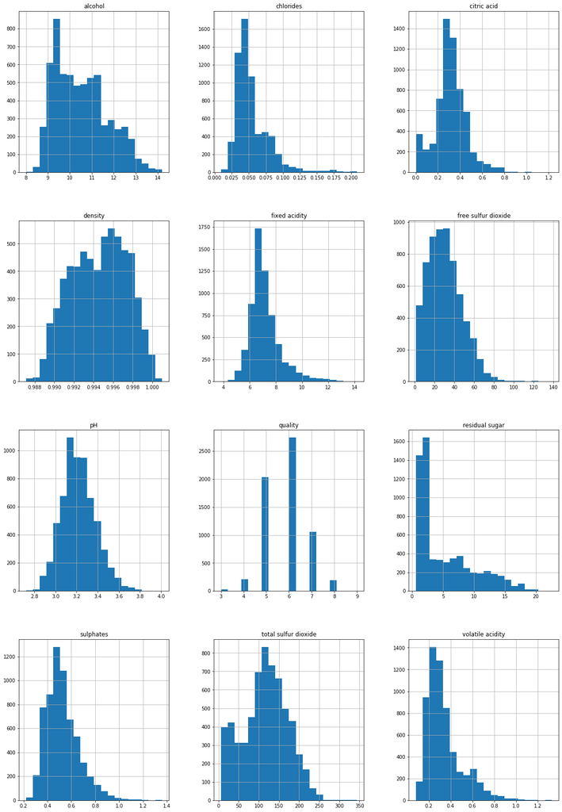

```python
df_out.hist(bins = 20,figsize=(20, 30))
plt.show()
```

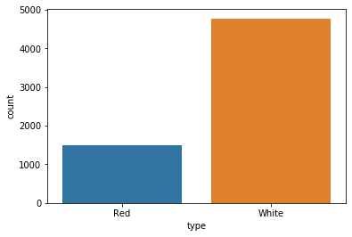

```python
sns.countplot(data=df_out, x="type")
plt.show()
```

### Regularização dos Dados

```python
df_out_dm = pd.get_dummies(df_out,drop_first=True)
```

```python
df_reg = df_out_dm
lista_sc =['fixed acidity','volatile acidity','citric acid','residual sugar','chlorides','free sulfur dioxide',
 'total sulfur dioxide', 'density', 'pH', 'sulphates', 'alcohol']
scaler = MinMaxScaler()
df_scaler = df_out[lista_sc]
scaled_values = scaler.fit_transform(df_scaler)
df_reg[lista_sc]= scaled_values
```

```python
df_reg.head()
```

|  | fixed acidity | volatile acidity | citric acid | residual sugar | chlorides | free sulfur dioxide | total sulfur dioxide | density | pH | sulphates | alcohol | quality | type_White |
| --- | --- | --- | --- | --- | --- | --- | --- | --- | --- | --- | --- | --- | --- |
| 0 | 0.307692 | 0.152 | 0.292683 | 0.913636 | 0.180 | 0.320000 | 0.485207 | 1.000000 | 0.217054 | 0.201754 | 0.129032 | 6 | 1 |
| 1 | 0.240385 | 0.176 | 0.276423 | 0.045455 | 0.200 | 0.094545 | 0.372781 | 0.496040 | 0.449612 | 0.236842 | 0.241935 | 6 | 1 |
| 2 | 0.413462 | 0.160 | 0.325203 | 0.286364 | 0.205 | 0.210909 | 0.269231 | 0.575234 | 0.418605 | 0.192982 | 0.338710 | 6 | 1 |
| 3 | 0.326923 | 0.120 | 0.260163 | 0.359091 | 0.245 | 0.334545 | 0.532544 | 0.611231 | 0.364341 | 0.157895 | 0.306452 | 6 | 1 |
| 4 | 0.326923 | 0.120 | 0.260163 | 0.359091 | 0.245 | 0.334545 | 0.532544 | 0.611231 | 0.364341 | 0.157895 | 0.306452 | 6 | 1 |

```python
df_reg.describe()
```

|  | fixed acidity | volatile acidity | citric acid | residual sugar | chlorides | free sulfur dioxide | total sulfur dioxide | density | pH | sulphates | alcohol | quality | type_White |
| --- | --- | --- | --- | --- | --- | --- | --- | --- | --- | --- | --- | --- | --- |
| count | 6263.000000 | 6263.000000 | 6263.000000 | 6263.000000 | 6263.000000 | 6263.000000 | 6263.000000 | 6263.000000 | 6263.000000 | 6263.000000 | 6263.000000 | 6263.000000 | 6263.000000 |
| mean | 0.322865 | 0.205742 | 0.256085 | 0.214946 | 0.223109 | 0.214689 | 0.324963 | 0.535378 | 0.388125 | 0.267651 | 0.405616 | 5.827718 | 0.763053 |
| std | 0.115057 | 0.130495 | 0.115538 | 0.206964 | 0.124154 | 0.125981 | 0.164688 | 0.203342 | 0.124565 | 0.119786 | 0.191665 | 0.872511 | 0.425244 |
| min | 0.000000 | 0.000000 | 0.000000 | 0.000000 | 0.000000 | 0.000000 | 0.000000 | 0.000000 | 0.000000 | 0.000000 | 0.000000 | 3.000000 | 0.000000 |
| 25% | 0.250000 | 0.120000 | 0.195122 | 0.054545 | 0.145000 | 0.116364 | 0.215976 | 0.370770 | 0.302326 | 0.184211 | 0.241935 | 5.000000 | 1.000000 |
| 50% | 0.307692 | 0.168000 | 0.252033 | 0.104545 | 0.190000 | 0.203636 | 0.331361 | 0.553636 | 0.379845 | 0.245614 | 0.387097 | 6.000000 | 1.000000 |
| 75% | 0.365385 | 0.256000 | 0.317073 | 0.336364 | 0.270000 | 0.290909 | 0.440828 | 0.697624 | 0.465116 | 0.333333 | 0.532258 | 6.000000 | 1.000000 |
| max | 1.000000 | 1.000000 | 1.000000 | 1.000000 | 1.000000 | 1.000000 | 1.000000 | 1.000000 | 1.000000 | 1.000000 | 1.000000 | 9.000000 | 1.000000 |

### Separando em categorias

```python
df_out['qualidade'] = df_out["quality"].apply(lambda x: 'baixa' if x <= 5 else 'media' if x <= 7 else 'alta')
```

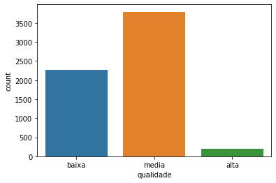

```python
sns.countplot(data=df_out, x="qualidade", order = ["baixa","media","alta"])
plt.show()
```

## 3. Análise exploratória dos dados

### Box Plots por variável e nota

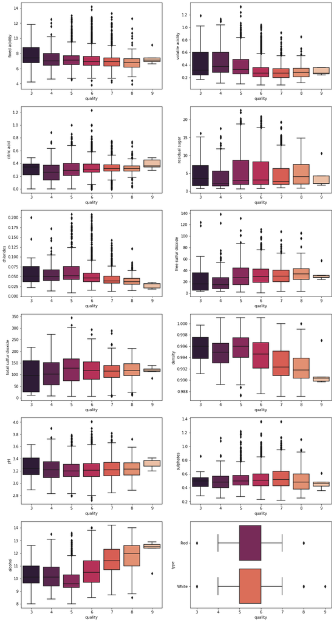

```python
fig = plt.figure(figsize=(15,30))
features = ['fixed acidity', 'volatile acidity', 'citric acid',
       'residual sugar', 'chlorides', 'free sulfur dioxide',
       'total sulfur dioxide', 'density', 'pH', 'sulphates', 'alcohol',"type"]

for i in range(12):
    ax1 = fig.add_subplot(6,2,i+1)
    sns.boxplot(x="quality", y=features[i],data=df_out, palette="rocket")
```

### Box plot por variável e qualidade

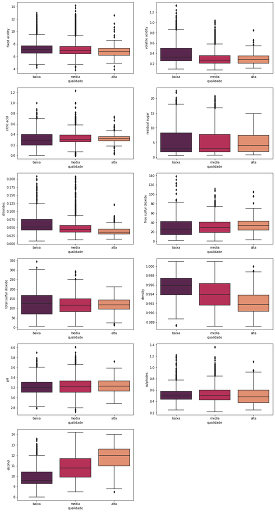

```python
fig = plt.figure(figsize=(15,30))
features = ['fixed acidity', 'volatile acidity', 'citric acid',
       'residual sugar', 'chlorides', 'free sulfur dioxide',
       'total sulfur dioxide', 'density', 'pH', 'sulphates', 'alcohol']


for i in range(11):
    ax1 = fig.add_subplot(6,2,i+1)
    sns.boxplot(x="qualidade", y=features[i],data=df_out, palette="rocket",order = ["baixa","media","alta"])
```

### Observações:

- Álcool parece ser uma variável importante, vinhos com qualidade alta estão associados com alta quantidade de ácool
- Densidade parece ser uma variável importante, vinhos com densidade baixa estão relacionadas com qualidade alta
- Chlorides parece ser uma variável importante, vinhos com chlorides baixo estão relacionadas com qualidade alta

### Comparando vinho Branco e Vermelho

#### Média por variável, tipo de vinho e nota

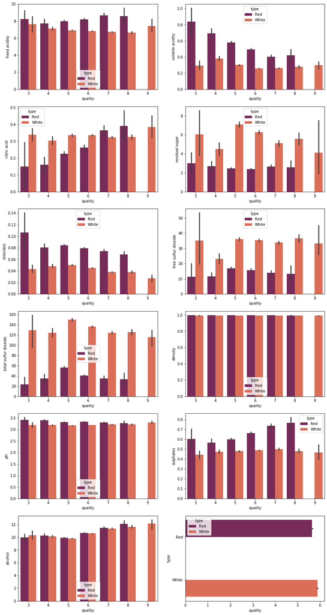

```python
fig = plt.figure(figsize=(15,30))
features = ['fixed acidity', 'volatile acidity', 'citric acid',
       'residual sugar', 'chlorides', 'free sulfur dioxide',
       'total sulfur dioxide', 'density', 'pH', 'sulphates', 'alcohol',"type"]

for i in range(12):
    ax1 = fig.add_subplot(6,2,i+1)
    sns.barplot(x='quality', y=features[i],data=df_out, hue='type', palette='rocket')
```

#### Média por variável, tipo de vinho e qualidade

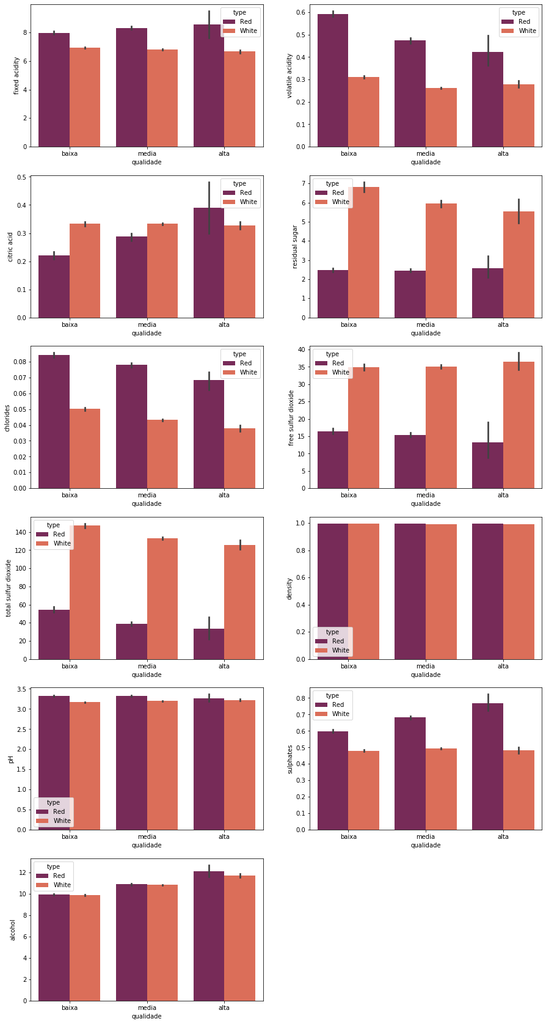

```python
fig = plt.figure(figsize=(15,30))
features = ['fixed acidity', 'volatile acidity', 'citric acid',
       'residual sugar', 'chlorides', 'free sulfur dioxide',
       'total sulfur dioxide', 'density', 'pH', 'sulphates', 'alcohol',"type"]

for i in range(11):
    ax1 = fig.add_subplot(6,2,i+1)
    sns.barplot(x='qualidade', y=features[i],data=df_out, hue='type',
                palette='rocket',order = ["baixa","media","alta"])
```

#### Box plots por variável, tipo de vinho e nota

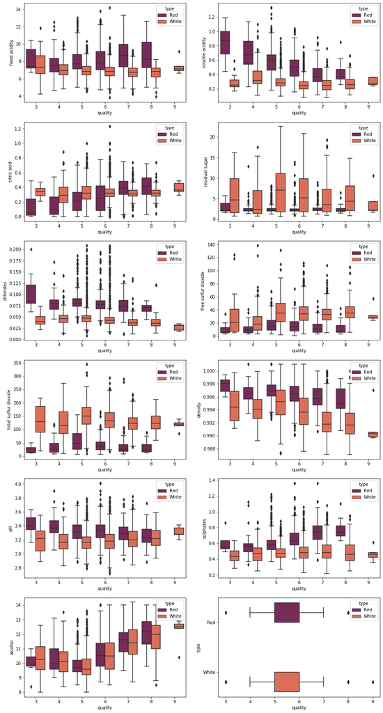

```python
fig = plt.figure(figsize=(15,30))
features = ['fixed acidity', 'volatile acidity', 'citric acid',
       'residual sugar', 'chlorides', 'free sulfur dioxide',
       'total sulfur dioxide', 'density', 'pH', 'sulphates', 'alcohol',"type"]

for i in range(12):
    ax1 = fig.add_subplot(6,2,i+1)
    sns.boxplot(x="quality", y=features[i],data=df_out, palette="rocket",hue = "type")
```

#### Box plots por variável, tipo de vinho e qualidade

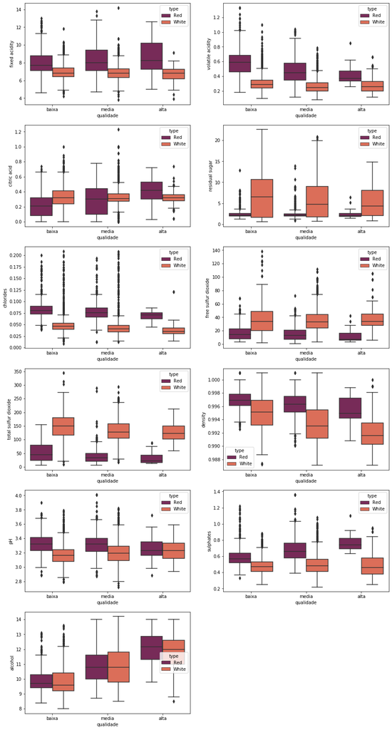

```python
fig = plt.figure(figsize=(15,30))
features = ['fixed acidity', 'volatile acidity', 'citric acid',
       'residual sugar', 'chlorides', 'free sulfur dioxide',
       'total sulfur dioxide', 'density', 'pH', 'sulphates', 'alcohol',"type"]

for i in range(11):
    ax1 = fig.add_subplot(6,2,i+1)
    sns.boxplot(x="qualidade", y=features[i],data=df_out,
                palette="rocket",hue = "type",order = ["baixa","media","alta"])
```

### Observações:

- O tipo de vinho é importante, visto que as variáveis se comportam de maneira diferente para cada tipo. Por exemplo: volatile acidity e sulphates é importante para vinhos do tipo vermelho e não para vinhos do tipo branco
- A comparação entre branco e vermelho será expandida a seguir

#### Calculando e visualizando a média das variáveis por tipo de vinho

```python
white = df_out[df_out["type"]=="White"]
red = df_out[df_out["type"]=="Red"]
```

```python
red.mean()
```

```
fixed acidity            8.162601
volatile acidity         0.528423
citric acid              0.257588
residual sugar           2.461624
chlorides                0.080718
free sulfur dioxide     15.874326
total sulfur dioxide    46.077493
density                  0.996551
pH                       3.322648
sulphates                0.643511
alcohol                 10.451853
quality                  5.642183
dtype: float64
```

```python
white.mean()
```

```
fixed acidity             6.845773
volatile acidity          0.277791
citric acid               0.332808
residual sugar            6.219157
chlorides                 0.045208
free sulfur dioxide      35.067483
total sulfur dioxide    137.499791
density                   0.993924
pH                        3.189019
sulphates                 0.488359
alcohol                  10.534371
quality                   5.885332
dtype: float64
```

### Comparando as médias por tipo de vinho

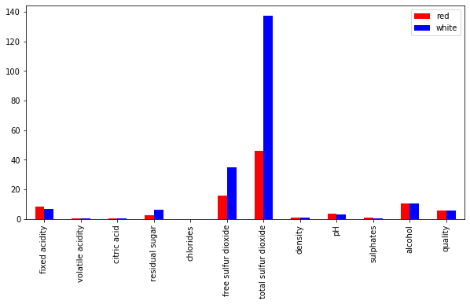

```python
mean = pd.concat([red.mean(),white.mean()], axis =1)
mean.rename(columns={0:'red',1:'white'},inplace=True)
mean.plot(kind = "bar",figsize=(10,5), color = ["red","blue"])
plt.show()
```

### Comparando baixa qualidade com alta qualidade por tipo de vinho

```python
#branco
white_group = white.groupby(["quality"]).mean()
baixa_qual = white_group.loc[:4].mean()
alta_qual = white_group.loc[7:].mean()
white_per = (alta_qual - baixa_qual) / white.mean() * 100
white_per
```

```
alcohol                 14.190326
chlorides              -25.015022
citric acid              7.129593
density                 -0.242322
fixed acidity           -6.618948
free sulfur dioxide     15.506370
pH                       1.772353
quality                       NaN
residual sugar          -5.568719
sulphates                5.000080
total sulfur dioxide    -3.460646
volatile acidity       -20.856944
dtype: float64
```

#### Exibindo variáveis onde a diferença entre vinhos do tipo branco bons e ruins é grande

```python
white_per[abs(white_per) > 10]
```

```
alcohol                14.190326
chlorides             -25.015022
free sulfur dioxide    15.506370
volatile acidity      -20.856944
dtype: float64
```

```python
#vermelho
red_group = red.groupby(["quality"]).mean()
baixa_qual = red_group.loc[:4].mean()
alta_qual = red_group.loc[7:].mean()
red_per = (alta_qual - baixa_qual) / red.mean() * 100
red_per
```

```
alcohol                 15.883074
chlorides              -27.470130
citric acid             86.239403
density                 -0.154048
fixed acidity            7.861290
free sulfur dioxide     13.977590
pH                      -3.622147
quality                       NaN
residual sugar          -8.285664
sulphates               26.130954
total sulfur dioxide    10.241804
volatile acidity       -66.684045
dtype: float64
```

#### Exibindo variáveis onde a diferença entre vinhos do tipo vermelho bons e ruins é grande

```python
red_per[abs(red_per) > 10]
```

```
alcohol                 15.883074
chlorides              -27.470130
citric acid             86.239403
free sulfur dioxide     13.977590
sulphates               26.130954
total sulfur dioxide    10.241804
volatile acidity       -66.684045
dtype: float64
```

#### Mostrando as diferenças entre vinhos bons e ruins por tipo

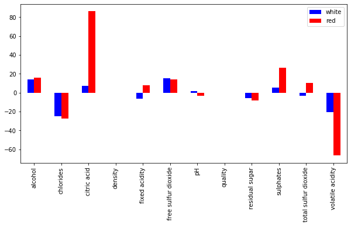

```python
comparacao = pd.concat([white_per,red_per], axis =1)
comparacao.rename(columns={0:'white',1:'red'},inplace=True)
comparacao.plot(kind = "bar",figsize=(10,5),color=["blue","red"])
plt.show()
```

### Análise Multivariada

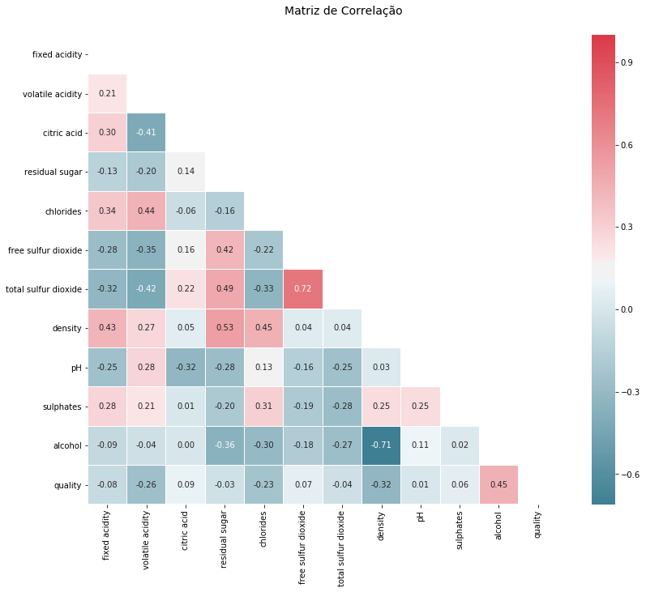

```python
f, ax = plt.subplots(figsize=(15, 10))
corr = df_out.corr()
mask = np.zeros_like(corr)
mask[np.triu_indices_from(mask)] = True
hm = sns.heatmap(round(corr,2), annot=True, ax=ax,
                 cmap=sns.diverging_palette(220, 10, as_cmap=True),fmt='.2f',
                  square=True,linewidths=.05,mask=mask)
f.subplots_adjust(top=0.93)
t= f.suptitle('Matriz de Correlação', fontsize=14)
```

### Observações:

- Em geral alcohol, density, chlorides e volatile acidity tem maior correlação com a variável de resposta qualidade

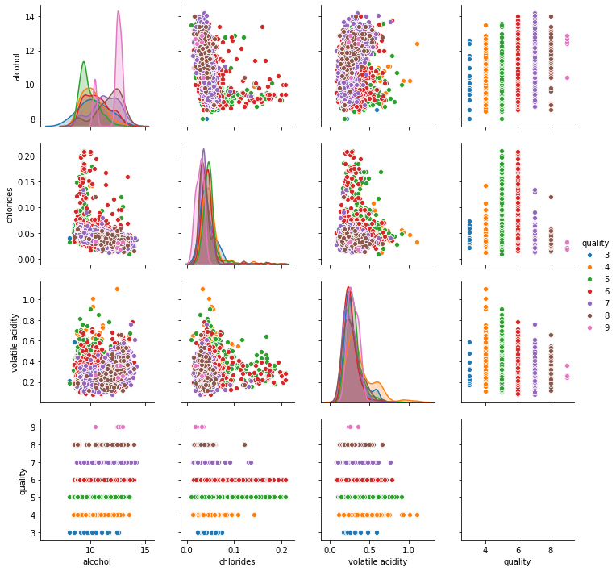

```python
sns.pairplot(white[["alcohol", "chlorides", "volatile acidity","quality"]],hue="quality")
plt.show()
```

### Análise Multivariada por tipo de vinho: Branco

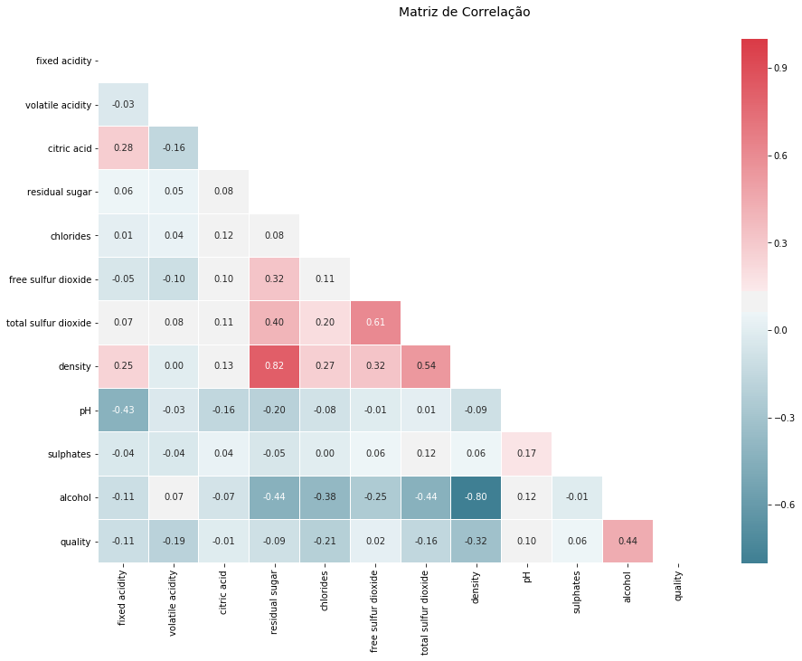

```python
f, ax = plt.subplots(figsize=(15, 10))
corr = white.corr()
mask = np.zeros_like(corr)
mask[np.triu_indices_from(mask)] = True
hm = sns.heatmap(round(corr,2), annot=True, ax=ax,
                 cmap=sns.diverging_palette(220, 10, as_cmap=True),
                 mask = mask,fmt='.2f',linewidths=.05)
f.subplots_adjust(top=0.93)
t= f.suptitle('Matriz de Correlação', fontsize=14)
```

### Observações:

- Para vinhos do tipo Branco, alcohol, density e clhorides tem maior correlação com a variável de resposta qualidade

#### Visualização das variáveis alcohol, density e clhorides

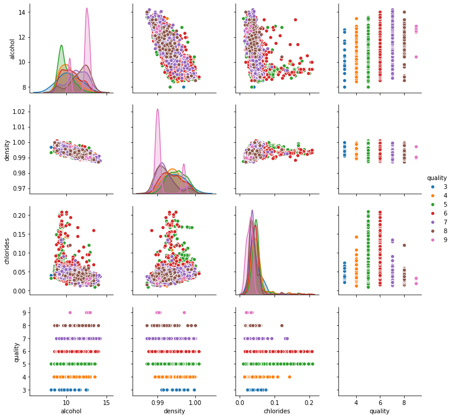

```python
sns.pairplot(white[["alcohol","density","chlorides","quality"]],hue="quality")
plt.show()
```

### Análise Multivariada por tipo de vinho: Vermelho

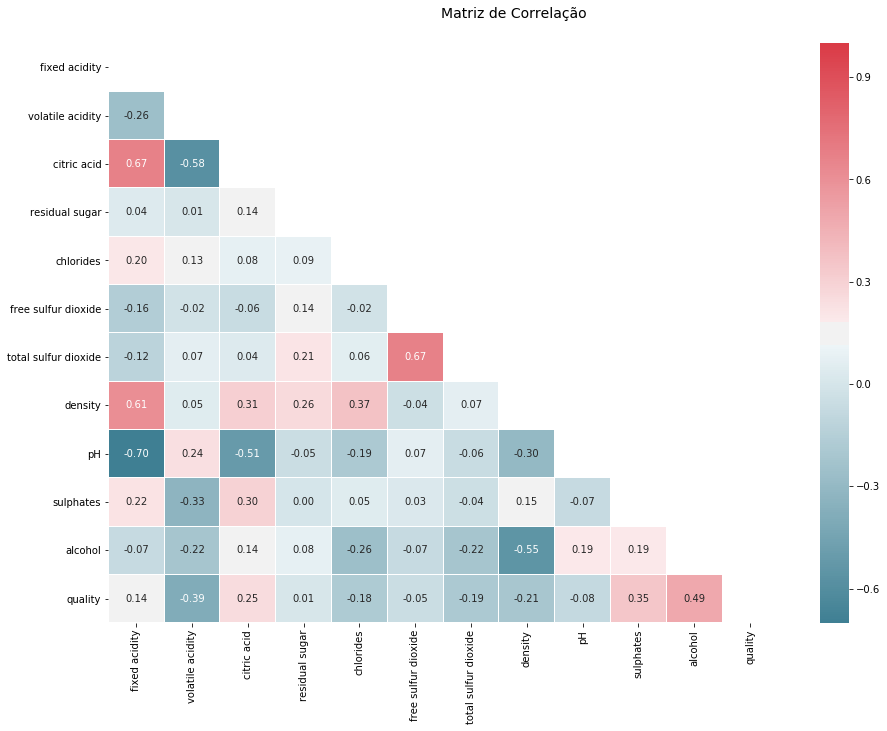

```python
f, ax = plt.subplots(figsize=(15, 10))
corr = red.corr()
mask = np.zeros_like(corr)
mask[np.triu_indices_from(mask)] = True
hm = sns.heatmap(round(corr,2), annot=True, ax=ax,
                 cmap=sns.diverging_palette(220, 10, as_cmap=True),
                 fmt='.2f',mask = mask,  linewidths=.05)
f.subplots_adjust(top=0.93)
t= f.suptitle('Matriz de Correlação', fontsize=14)
```

### Observações:

- Para vinhos do tipo Vermelho, alcohol, sulphates e volatile acidity tem maior correlação com a variável de resposta

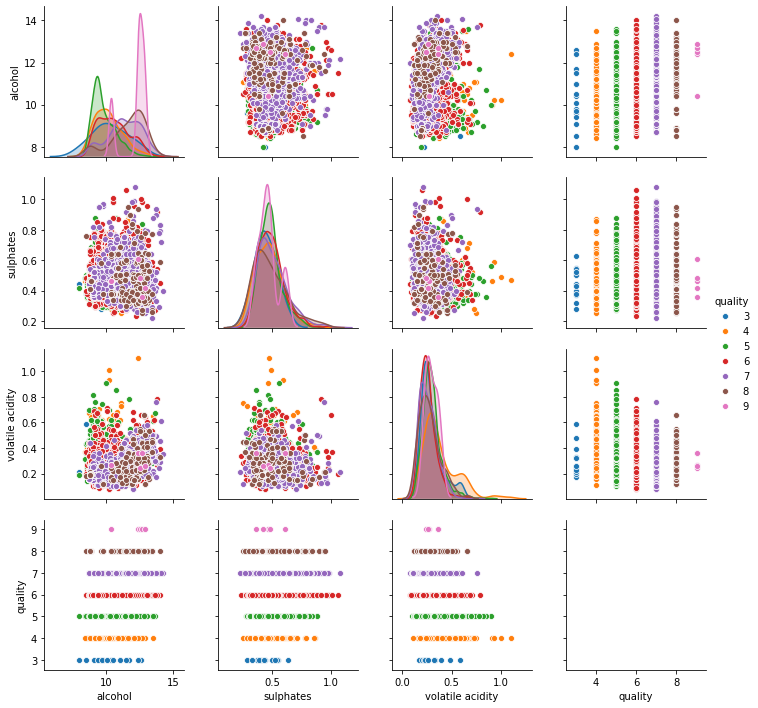

```python
sns.pairplot(white[["alcohol","sulphates","volatile acidity","quality"]],hue="quality")
plt.show()
```

## 4. Testes com Modelos

### Criando as variáveis de entrada e saída para dados regularizados

```python
X_reg = df_reg[['fixed acidity', 'volatile acidity', 'citric acid', 'residual sugar',
               'chlorides', 'free sulfur dioxide', 'total sulfur dioxide', 'density',
               'pH', 'sulphates', 'alcohol', 'type_White']]
y_reg = df_reg["quality"]
```

```python
X_reg.shape,y_reg.shape
```

```
((6263, 12), (6263,))
```

### Criando as variáveis de entrada e saída para dados sem regularização

```python
df_out = pd.get_dummies(df_out,drop_first=True)
```

```python
X = df_out[['fixed acidity', 'volatile acidity', 'citric acid', 'residual sugar',
               'chlorides', 'free sulfur dioxide', 'total sulfur dioxide', 'density',
               'pH', 'sulphates', 'alcohol', 'type_White']]
y = df_out["quality"]
```

```python
X.shape,y.shape
```

```
((6263, 12), (6263,))
```

### Criando um baseline atribuindo a média como previsão

```python
db_media = np.mean(y_reg)
db_vec = np.ones(len(y_reg))*db_media
baseline = np.sqrt(mean_squared_error(y_true=y_reg, y_pred=db_vec))
```

```python
print("Baseline: "+ str(baseline)[:4])
```

```
Baseline: 0.87
```

### Usando cross validation para modelos diferentes

```python
kf = KFold(n_splits = 20, random_state = 10,shuffle = True)
```

```python
linr = LinearRegression()
svma = svm.SVR()
lin_svmr = svm.LinearSVR()
lrg= LogisticRegression(max_iter=10000)
xgbr = xgb.XGBRegressor(objective ='reg:squarederror')
dt = DecisionTreeRegressor()
```

```python
model = [linr,svma,lin_svmr,lrg,xgbr,dt]
```

```python
model_str = ["Regressão Linear","SVM","Linear SVM","Regressão Logística","Xgboost","Árvore de decisão"]
```

```python
scores_model=[]

for md in model:

    scores=[]

    for train_index, test_index in kf.split(X):


        X_train, X_test, y_train, y_test = X_reg.iloc[train_index], X_reg.iloc[test_index], y_reg.iloc[train_index], y_reg.iloc[test_index]
        md.fit(X_train,y_train)
        y_prediction = md.predict(X_test)
        scores.append(np.sqrt(mean_squared_error(y_true=y_test, y_pred=y_prediction)))


    scores_model.append(np.mean(scores))
```

```python
for i in range(len(model)):
    print("Modelo: "+str(model_str[i]) +"." + "RMSE: " + str(scores_model[i]) )
```

```
Modelo: Regressão Linear.RMSE: 0.7304020903218442
Modelo: SVM.RMSE: 0.7252364607259152
Modelo: Linear SVM.RMSE: 0.733738620418796
Modelo: Regressão Logística.RMSE: 0.8110080788697316
Modelo: Xgboost.RMSE: 0.6226059391386638
Modelo: Árvore de decisão.RMSE: 0.8079365230739841
```

### Grid search para XGBoost

```python
folds = 5
param_comb = 72

skf = StratifiedKFold(n_splits=folds, shuffle = True, random_state = 1001)
```

```python
params = {
        'learning_rate=': [0.1,0.15,0.2],
        'max_depth': [5,10,12,15,20,25],
        'n_estimators': [50,100,150,200]
        }
```

```python
xgb_grid = xgb.XGBRegressor(objective='reg:squarederror',silent=False, nthread=1)
```

```python
random_search = RandomizedSearchCV(xgb_grid, param_distributions=params, n_iter=param_comb, scoring='neg_mean_squared_error',
                                   n_jobs=-1, cv=skf.split(X,y), verbose = 1, random_state=1001 )
```

```python
random_search.fit(X, y)
```

```
Fitting 5 folds for each of 72 candidates, totalling 360 fits
```

```
[Parallel(n_jobs=-1)]: Using backend LokyBackend with 4 concurrent workers.
[Parallel(n_jobs=-1)]: Done  42 tasks      | elapsed:   18.9s
[Parallel(n_jobs=-1)]: Done 192 tasks      | elapsed:  1.5min
[Parallel(n_jobs=-1)]: Done 360 out of 360 | elapsed:  2.8min finished
```

```
RandomizedSearchCV(cv=<generator object _BaseKFold.split at 0x7fdae1474ed0>,
                   error_score='raise-deprecating',
                   estimator=XGBRegressor(base_score=None, booster=None,
                                          colsample_bylevel=None,
                                          colsample_bynode=None,
                                          colsample_bytree=None, gamma=None,
                                          gpu_id=None, importance_type='gain',
                                          interaction_constraints=None,
                                          learning_rate=None,
                                          max_delta_step=None, max_depth=Non...
                                          scale_pos_weight=None, silent=False,
                                          subsample=None, tree_method=None,
                                          validate_parameters=False,
                                          verbosity=None),
                   iid='warn', n_iter=72, n_jobs=-1,
                   param_distributions={'learning_rate=': [0.1, 0.15, 0.2],
                                        'max_depth': [5, 10, 12, 15, 20, 25],
                                        'n_estimators': [50, 100, 150, 200]},
                   pre_dispatch='2*n_jobs', random_state=1001, refit=True,
                   return_train_score=False, scoring='neg_mean_squared_error',
                   verbose=1)
```

```python
melhores_parametros = random_search.best_params_
```

```python
print("Melhores parâmetros: " + str(melhores_parametros))
```

```
Melhores parâmetros: {'n_estimators': 200, 'max_depth': 15, 'learning_rate=': 0.1}
```

```python
m_parametros_l = list(melhores_parametros.values())
```

### Testando o xgboost com os parametros obtidos no grid search

```python
xgb_teste = xgb.XGBRegressor(objective ='reg:squarederror',
                             n_estimators = m_parametros_l[0],
                             max_depth= m_parametros_l[1],
                             learning_rate= m_parametros_l[2] )
```

```python
scores=[]

for train_index, test_index in kf.split(X):


    X_train, X_test, y_train, y_test = X_reg.iloc[train_index], X_reg.iloc[test_index], y_reg.iloc[train_index], y_reg.iloc[test_index]
    xgb_teste.fit(X_train,y_train)
    y_prediction = xgb_teste.predict(X_test)
    scores.append(np.sqrt(mean_squared_error(y_true=y_test, y_pred=y_prediction)))
```

```python
for i in range(len(scores)):
    print("Folder: "+ str(i)+ ". RMSE: "+ str(scores[i])[:4])
media_rmse = np.mean(scores)
print("Média RMSE:      "+ str(media_rmse)[:4])
```

```
Folder: 0. RMSE: 0.55
Folder: 1. RMSE: 0.57
Folder: 2. RMSE: 0.55
Folder: 3. RMSE: 0.58
Folder: 4. RMSE: 0.54
Folder: 5. RMSE: 0.57
Folder: 6. RMSE: 0.58
Folder: 7. RMSE: 0.61
Folder: 8. RMSE: 0.62
Folder: 9. RMSE: 0.63
Folder: 10. RMSE: 0.63
Folder: 11. RMSE: 0.60
Folder: 12. RMSE: 0.56
Folder: 13. RMSE: 0.63
Folder: 14. RMSE: 0.58
Folder: 15. RMSE: 0.62
Folder: 16. RMSE: 0.53
Folder: 17. RMSE: 0.61
Folder: 18. RMSE: 0.55
Folder: 19. RMSE: 0.60
Média RMSE:      0.58
```

```python
print("O modelo com esses parâmetros é: " + str((1-media_rmse/baseline)*100)[:4] + "% melhor que a média")
```

```
O modelo com esses parâmetros é: 32.4% melhor que a média
```

## 5. Apresentação do modelo final

Utilizando os parâmetros encontrados acima apresento um modelo de teste (modelo_teste.bin) treinado em 80% dos dados.

Os 20% de dados utilizados para teste serão salvos em resultado.csv, contendo o original e a previsão.

O modelo gerado com todos os dados será salvo em modelo.bin.

Para fazer a previsão de um vinho com esse modelo basta usar apply_model.ipynb

```python
model = xgb.XGBRegressor(objective ='reg:squarederror',
                             n_estimators = m_parametros_l[0],
                             max_depth= m_parametros_l[1],
                             learning_rate= m_parametros_l[2] )
```

```python
X_train, X_test, y_train, y_test = train_test_split(X, y, test_size=0.2, random_state=10)
```

```python
model.fit(X_train,y_train)
```

```
XGBRegressor(base_score=0.5, booster=None, colsample_bylevel=1,
             colsample_bynode=1, colsample_bytree=1, gamma=0, gpu_id=-1,
             importance_type='gain', interaction_constraints=None,
             learning_rate=0.1, max_delta_step=0, max_depth=15,
             min_child_weight=1, missing=nan, monotone_constraints=None,
             n_estimators=200, n_jobs=0, num_parallel_tree=1,
             objective='reg:squarederror', random_state=0, reg_alpha=0,
             reg_lambda=1, scale_pos_weight=1, subsample=1, tree_method=None,
             validate_parameters=False, verbosity=None)
```

```python
y_prediction = model.predict(X_test)
```

```python
RMSE = np.sqrt(mean_squared_error(y_true=y_test, y_pred=y_prediction))
print("RMSE: "+ str(RMSE)[:4])
```

```
RMSE: 0.59
```

#### Variáveis mais importantes

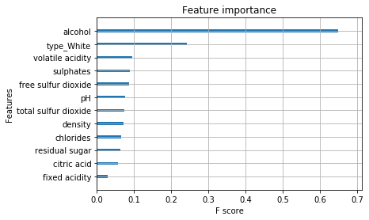

```python
xgb.plot_importance(model, importance_type="gain", show_values=False)
plt.show()
```

#### Arvore de decisão

Obs: Caso a resolução não esteja boa uma imagem separada (arvore.png) foi disponibilizada na pasta. Essa arvore está limitada e não contém todos os ramos, apenas o iniciais.

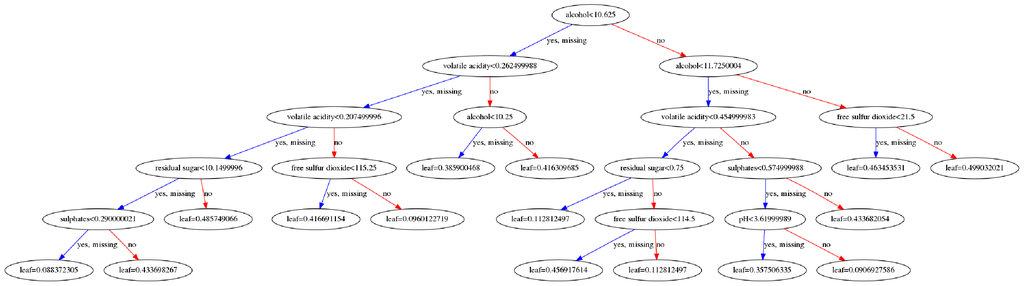

```python
fig, ax = plt.subplots(figsize = (50,50))
xgb.plot_tree(model, ax=ax, num_trees=2)
plt.show()
```

#### Salvando o modelo para futuras análises

```python
model.save_model('modelo_teste.bin')
```

#### Salvando dados de teste para análise

```python
resultado = pd.DataFrame( columns=["original","previsto"])
resultado["original"] = y_test
resultado["previsto"] = y_prediction
```

```python
resultado.tail()
```

|  | original | previsto |
| --- | --- | --- |
| 5263 | 6 | 6.543643 |
| 946 | 5 | 4.519495 |
| 4791 | 6 | 5.998261 |
| 2816 | 5 | 6.159513 |
| 2758 | 6 | 5.800340 |

```python
resultado.to_csv("resultado.csv",index = False)
```

### Criando um modelo com todos os dados possíveis

No arquivo apply_model.ipynb é possível fazer a execução desse modelo de forma pontual

```python
modelo_final = xgb.XGBRegressor(objective ='reg:squarederror',
                             n_estimators = m_parametros_l[0],
                             max_depth= m_parametros_l[1],
                             learning_rate= m_parametros_l[2] )
modelo_final.fit(X,y)
modelo_final.save_model('modelo.bin')
```

## Observações finais:

- Foi obtido um modelo com erro médio de 0.58 realizando a validação cruzada, esse resultado é 32% melhor que o baseline o que comprova a qualidade do modelo. Esse foi o menor erro encontrado em todos os modelos testados
- Como observado na análise exploratória Álcool e o tipo de Vinho são os principais fatores para determinar a qualidade
- Um ponto interessante é que apesar do tipo do vinho ser importante para determinação da qualidade do vinho, o tipo não aparece no começo da árvore de decisão
- Foram testadas outras abordagens que não entraram nesse relatório para que não ficasse muito extenso. Uma delas foi separar o conjunto em vinho branco e tinto. Porém, essa abordagem não obteve ganho significativo de performance e foi descartada
- Como sugestão para melhorar o resultado do modelo poderia ser realizado a abordagem de classificação e em um segundo momento tentar unir as duas abordagens